# MLH1 Results Outline

04 February 2020

# Models Framework

These are the basic Mixed Models we used as a frame work to analyze all the MLH1 count data.

$$mouse \ av.\ metric ~=~ subsp * sex + rand(strain) + \varepsilon$$

The mixed model lets us separate effects to see how they effect a mouse mean CO count. The subspecies effect is a proxy for **Divergence** and the random strain effect is a proxy for **Polymorphism**.

Setting up the data set for using the mixed model (base data set, HQ data set)

- only Mus musculus strains with sex matched observations
- Male gwRR have been adjusted for the PAR
- Q5 excluded
- All the effects are unorder factors
- male ages within 5 - 20 weeks
- Molossinus is coded as a subsp level

This is the break down of mice used within the Mixed model

|  | WSB | G | LEW | PWD | MSM | MOLF | SKIVE | KAZ |
| --- | --- | --- | --- | --- | --- | --- | --- | --- |
| female | 14 | 12 | 9 | 15 | 14 | 1 | 1 | 9 |
| male | 10 | 11 | 7 | 8 | 4 | 6 | 5 | 11 |

subspecies levels: 3, Musc, Dom and Molossinus

strain levels: Dom: 3, Musc: 3 Mol: 2

sex: 2 female male

For now I will focus on 3 different models for comparing the subsp, sex and strain effects across relevant dependant variables.

1. $$mouse \ av \ meteric ~=~ subsp * sex + rand(1|strain) + \varepsilon$$

Allows random effect from strain. Considers the wild derived inbred strains as random samples from each subspecies territory.

2. $$mouse \ av \ meteric ~=~ subsp * sex * strain + \varepsilon$$

Post hoc model for investigating strain as a fixed effect.

3. $$mouse \ av \ meteric ~=~ sex * strain + \varepsilon$$

Used after it’s apparent strain has a significant effect - another post-hoc examination for strain as a fixed effect.

## MLH1 count M1

$$mouse .mean CO ~=~ subsp * sex + rand(1|strain) + \varepsilon$$

|  | Df | AIC | LRT | Pr(Chi) |
| --- | --- | --- | --- | --- |
|  | NA | 593.6954 | NA | NA |
| subsp:sex | 2 | 606.6854 | 16.99003 | 0.0002044854 |

|  | Estimate | Std. Error | t value |
| --- | --- | --- | --- |
| (Intercept) | 26.348630 | 1.038563 | 25.370273 |
| subspMol | -0.520512 | 1.717462 | -0.303070 |
| subspMusc | -0.724686 | 1.501886 | -0.482517 |
| sexmale | -1.628287 | 0.480734 | -3.387088 |
| subspMol:sexmale | 3.274996 | 1.042583 | 3.141233 |
| subspMusc:sexmale | 2.909844 | 0.743792 | 3.912177 |

|  | Df | Sum Sq | Mean Sq | F value |
| --- | --- | --- | --- | --- |
| subsp | 2 | 1.7310032 | 0.8655016 | 0.2414260 |
| sex | 1 | 0.5447656 | 0.5447656 | 0.1519588 |
| subsp:sex | 2 | 70.2197970 | 35.1098985 | 9.7936764 |

```
##
##  simulated finite sample distribution of RLRT.
##
##  (p-value based on 10000 simulated values)
##
## data:
## RLRT = 26.933, p-value < 2.2e-16
```

Above is the mixed model M1,

## MLH1 count M2

$$mouse \ av \ metric ~=~ subsp * sex * strain + \varepsilon$$

|  | Df | Sum Sq | Mean Sq | F value | Pr(>F) |
| --- | --- | --- | --- | --- | --- |
| subsp | 2 | 60.936936 | 30.468468 | 10.847566 | 4.642595e-05 |
| sex | 1 | 7.761507 | 7.761507 | 2.763298 | 9.903769e-02 |
| strain | 5 | 149.920165 | 29.984033 | 10.675095 | 1.635012e-08 |
| subsp:sex | 2 | 76.443439 | 38.221720 | 13.607925 | 4.670771e-06 |
| sex:strain | 5 | 111.155138 | 22.231028 | 7.914823 | 1.766099e-06 |
| Residuals | 121 | 339.862841 | 2.808784 | NA | NA |

|  | Estimate | Std. Error | t value | Pr(>\|t\|) |
| --- | --- | --- | --- | --- |
| (Intercept) | 24.711643 | 0.447915 | 55.170444 | 0.000000 |
| subspMol | 2.907357 | 1.734765 | 1.675937 | 0.096333 |
| subspMusc | 0.855690 | 0.716041 | 1.195030 | 0.234412 |
| sexmale | -0.156443 | 0.693906 | -0.225452 | 0.822008 |
| strainG | 3.297524 | 0.659312 | 5.001459 | 0.000002 |
| strainLEW | 1.696468 | 0.716041 | 2.369234 | 0.019408 |
| strainPWD | 0.302533 | 0.706639 | 0.428130 | 0.669318 |
| strainMSM | 0.069857 | 1.734765 | 0.040269 | 0.967945 |
| strainSKIVE | 0.370667 | 1.766599 | 0.209819 | 0.834162 |
| subspMol:sexmale | -3.222557 | 1.938665 | -1.662256 | 0.099050 |

[output cut: 6 more lines]

Above is the table of coefficients for MM.3, HQ data set, lm function, sex, strain and subsp are interacting fixed effects.

interaction terms of sex and strain for (G, MSM, PWD).

How are these models different from the last one – MM4 is missing subsp, so only sex * strain effects.

## MLH1 count M3

$$mouse \ av \ metric ~=~ sex * strain + \varepsilon$$

|  | Estimate | Std. Error | t value | Pr(>\|t\|) |
| --- | --- | --- | --- | --- |
| (Intercept) | 24.711643 | 0.447915 | 55.170444 | 0.000000 |
| sexmale | -0.156443 | 0.693906 | -0.225452 | 0.822008 |
| strainG | 3.297524 | 0.659312 | 5.001459 | 0.000002 |
| strainLEW | 1.696468 | 0.716041 | 2.369234 | 0.019408 |
| strainPWD | 1.158224 | 0.622800 | 1.859705 | 0.065356 |
| strainMSM | 2.977214 | 0.633447 | 4.700023 | 0.000007 |
| strainMOLF | 2.907357 | 1.734765 | 1.675937 | 0.096333 |
| strainSKIVE | 1.226357 | 1.734765 | 0.706930 | 0.480969 |
| strainKAZ | 0.855690 | 0.716041 | 1.195030 | 0.234412 |
| sexmale:strainG | -3.171906 | 0.985350 | -3.219064 | 0.001651 |

[output cut: 6 more lines]

## Male Specific Polymorphism

Follow up on this finding – included more strains which were excluded from the HetC analysis.

– what’s the driving question for this section –

> is there a strain effect in Dom?

> How different are the Musc strains?

test a model for fixed effects of strains within musc. The purpose is to distinguihsi musc strains from low ‘Dom’ level strains.

```
##
##   WSB     G   LEW  PERC   PWD   MSM  MOLF SKIVE   KAZ   TOM   AST CZECH
##    12    18    10     1     8     8     6     6    13     2     3     3
##  CAST   HMI
##     2     4
```

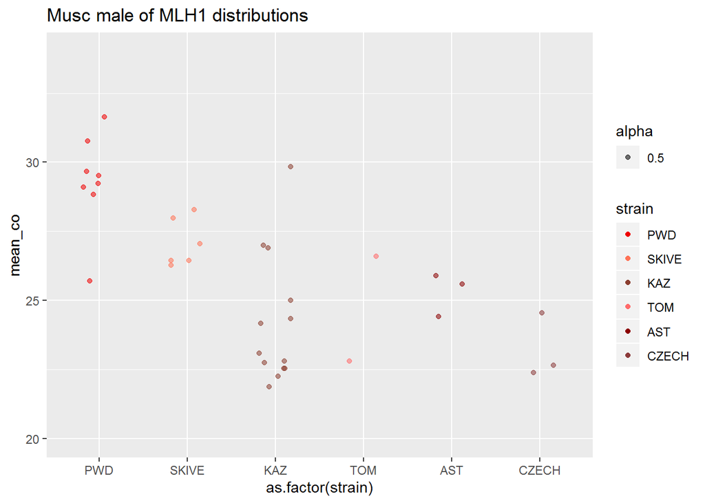

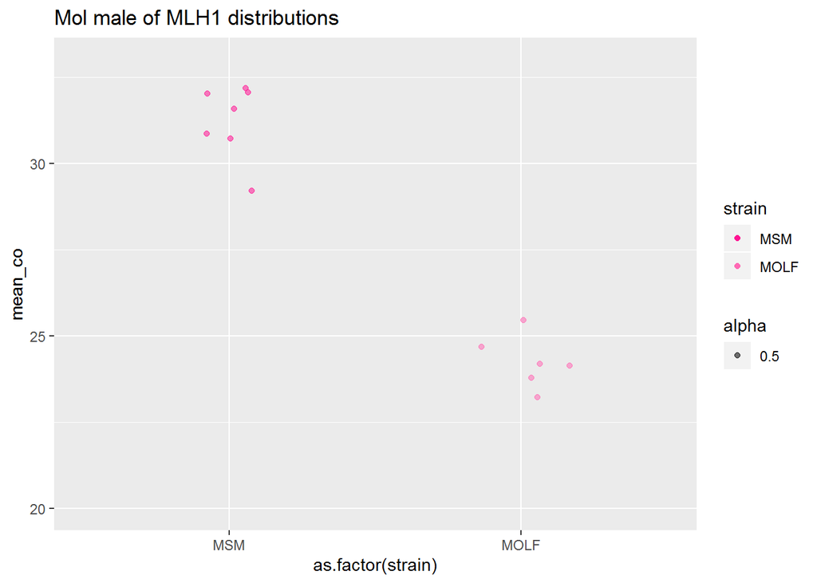

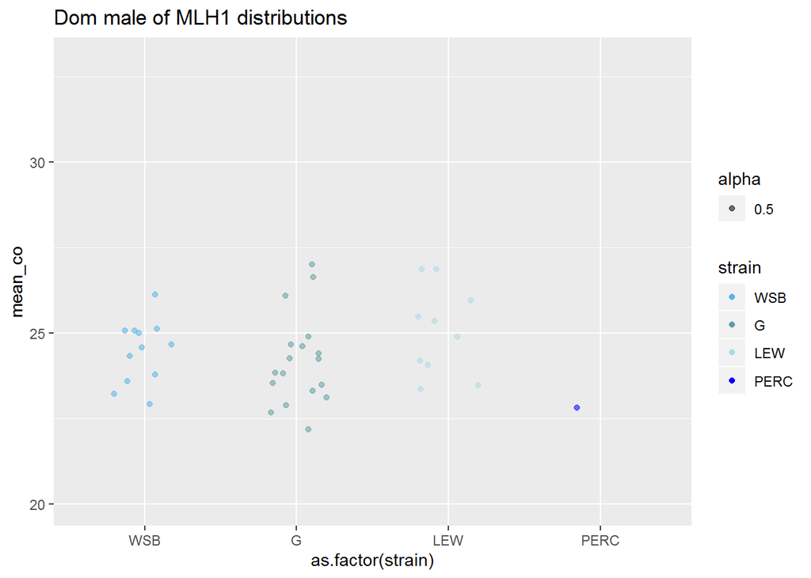

This is the table and plot of new Musc strains

| Var1 | Freq |
| --- | --- |
| PWD | 8 |
| SKIVE | 6 |
| KAZ | 13 |
| TOM | 2 |
| AST | 3 |
| CZECH | 3 |

Given the plot, make note of the potential outlier mice. The strains have unequal variance

KAZ: 10jul19_KAZ_m3, 10jul19_KAZ_m1, 10jul19_KAZ_m2

PWD: 24sep14_PWD_m1, 18may15_PWD_m1?

```
##           (Intercept)             subspCast             subspMusc
##           24.45316667           -0.09891667           -1.25950000
##              subspMol               strainG             strainLEW
##           -0.21316667           -0.25627778            0.59053333
##            strainPERC             strainPWD             strainMSM
##           -1.64516667            6.11270833            7.21425000
##            strainMOLF           strainSKIVE             strainKAZ
##                    NA            3.88183333            1.03964103
##             strainTOM             strainAST           strainCZECH
##            1.50633333            2.10533333                    NA
##            strainCAST             strainHMI     subspCast:strainG
##           -1.34525000                    NA                    NA
##     subspMusc:strainG      subspMol:strainG   subspCast:strainLEW
##                    NA                    NA                    NA
##   subspMusc:strainLEW    subspMol:strainLEW  subspCast:strainPERC
##                    NA                    NA                    NA
##  subspMusc:strainPERC   subspMol:strainPERC   subspCast:strainPWD
##                    NA                    NA                    NA
##   subspMusc:strainPWD    subspMol:strainPWD   subspCast:strainMSM
##                    NA                    NA                    NA
##   subspMusc:strainMSM    subspMol:strainMSM  subspCast:strainMOLF
##                    NA                    NA                    NA
##  subspMusc:strainMOLF   subspMol:strainMOLF subspCast:strainSKIVE
##                    NA                    NA                    NA
## subspMusc:strainSKIVE  subspMol:strainSKIVE   subspCast:strainKAZ
##                    NA                    NA                    NA
##   subspMusc:strainKAZ    subspMol:strainKAZ   subspCast:strainTOM
##                    NA                    NA                    NA
##   subspMusc:strainTOM    subspMol:strainTOM   subspCast:strainAST
##                    NA                    NA                    NA
##   subspMusc:strainAST    subspMol:strainAST subspCast:strainCZECH
##                    NA                    NA                    NA
## subspMusc:strainCZECH  subspMol:strainCZECH  subspCast:strainCAST
##                    NA                    NA                    NA
##  subspMusc:strainCAST   subspMol:strainCAST   subspCast:strainHMI
##                    NA                    NA                    NA
##   subspMusc:strainHMI    subspMol:strainHMI
##                    NA                    NA
```

msm, pwd skive are when all other male strains are added. skive is less sig than the others – but it’s still sig. Given these results I can group SKIVE, PWD and MSM into the ‘high rec’ group.

*PWD, MSM, SKIVE are in ‘high rec group’*

## Within Mouse Variance in CO Count per Cell

A general pattern is that the female data has higher within mouse variance (both var and cV). Some strains more than others (invetigate potential outliers). (LEW females with top 3 variance are all from different dissection dates) This pattern also holds for within mouse cv for MLH1 count (not shown).

**todo**

Test if dissection date is more significant predictor than strain (for females) (Effect doc) Also test how the number of 0CO bivalents per cell affects mouse with variance. (lm)

### Modeling Within Mouse Variance

(use the same models are mean_co, )

XXX (old 1.) HetC.MixedModel.HQ <- lme(mouse.metric ~ subsp*sex, data=DF.HetC.MixedModel.HQ, random=list(strain=pdDiag(~sex) ) )

1.(new 1) Reduced.strain.HQ <- lmer(mouse.metric ~ subsp * sex+ (1|strain), data=DF.HetC.MixedModel.HQ)

3. lm(mouse.metric ~ subsp * sex * strain, data=DF.HetC.MixedModel.HQ)
4. lm(mouse.metric ~ sex * strain, data=DF.HetC.MixedModel.HQ)

$$mouse metric ~=~ subsp * sex + rand(strain)+ \varepsilon$$

```
## Linear mixed model fit by REML ['lmerMod']
## Formula: var ~ subsp * sex + (1 | strain)
##    Data: DF.HetC.MixedModel.HQ
##
## REML criterion at convergence: 843.7
##
## Scaled residuals:
##     Min      1Q  Median      3Q     Max
## -2.1927 -0.5396 -0.0875  0.3379  3.3644
##
## Random effects:
##  Groups   Name        Variance Std.Dev.
##  strain   (Intercept)  2.528   1.590
##  Residual             30.989   5.567
## Number of obs: 137, groups:  strain, 8
##
## Fixed effects:
##                   Estimate Std. Error t value
## (Intercept)        15.1483     1.3184  11.490
## subspMol           -0.4944     2.3839  -0.207
## subspMusc          -1.9539     2.0133  -0.971
## sexmale            -7.9235     1.4128  -5.608
## subspMol:sexmale    0.5890     2.8447   0.207
## subspMusc:sexmale   1.5953     2.1583   0.739
##
## Correlation of Fixed Effects:
##             (Intr) sbspMl sbspMs sexmal sbspMl:
## subspMol    -0.553
## subspMusc   -0.655  0.362
## sexmale     -0.476  0.263  0.312
## sbspMl:sxml  0.236 -0.547 -0.155 -0.497
## sbspMsc:sxm  0.312 -0.172 -0.526 -0.655  0.325
```

|  | Df | AIC | LRT | Pr(Chi) |
| --- | --- | --- | --- | --- |
|  | NA | 875.0270 | NA | NA |
| subsp:sex | 2 | 871.5889 | 0.561917 | 0.7550597 |

|  | Df | Sum Sq | Mean Sq | F value |
| --- | --- | --- | --- | --- |
| subsp | 2 | 34.64438 | 17.322192 | 0.5589834 |
| sex | 1 | 1697.34342 | 1697.343422 | 54.7729009 |
| subsp:sex | 2 | 16.96731 | 8.483654 | 0.2737657 |

```
##
##  simulated finite sample distribution of RLRT.
##
##  (p-value based on 10000 simulated values)
##
## data:
## RLRT = 2.4256, p-value = 0.0404
```

|  | Estimate | Std. Error | t value |
| --- | --- | --- | --- |
| (Intercept) | 15.148325 | 1.318433 | 11.489646 |
| subspMol | -0.494389 | 2.383888 | -0.207387 |
| subspMusc | -1.953908 | 2.013258 | -0.970521 |
| sexmale | -7.923511 | 1.412786 | -5.608430 |
| subspMol:sexmale | 0.589028 | 2.844681 | 0.207063 |
| subspMusc:sexmale | 1.595256 | 2.158320 | 0.739119 |

```
## Linear mixed model fit by REML ['lmerMod']
## Formula: cV ~ subsp * sex + (1 | strain)
##    Data: DF.HetC.MixedModel.HQ
##
## REML criterion at convergence: 654.5
##
## Scaled residuals:
##     Min      1Q  Median      3Q     Max
## -3.2750 -0.5172 -0.0026  0.5824  2.4419
##
## Random effects:
##  Groups   Name        Variance Std.Dev.
##  strain   (Intercept) 0.547    0.7396
##  Residual             7.321    2.7058
## Number of obs: 137, groups:  strain, 8
##
## Fixed effects:
##                   Estimate Std. Error t value
## (Intercept)        14.0930     0.6276  22.456
## subspMol           -0.2205     1.1369  -0.194
## subspMusc          -0.4109     0.9598  -0.428
## sexmale            -3.6022     0.6867  -5.246
## subspMol:sexmale   -0.4417     1.3782  -0.320
## subspMusc:sexmale  -0.5531     1.0484  -0.528
##
## Correlation of Fixed Effects:
##             (Intr) sbspMl sbspMs sexmal sbspMl:
## subspMol    -0.552
## subspMusc   -0.654  0.361
## sexmale     -0.486  0.268  0.318
## sbspMl:sxml  0.242 -0.553 -0.158 -0.498
## sbspMsc:sxm  0.318 -0.176 -0.535 -0.655  0.326
```

|  | Df | AIC | LRT | Pr(Chi) |
| --- | --- | --- | --- | --- |
|  | NA | 676.9629 | NA | NA |
| subsp:sex | 2 | 673.2088 | 0.2459527 | 0.8842846 |

|  | Df | Sum Sq | Mean Sq | F value |
| --- | --- | --- | --- | --- |
| subsp | 2 | 10.896069 | 5.448035 | 0.7441460 |
| sex | 1 | 484.514312 | 484.514312 | 66.1797130 |
| subsp:sex | 2 | 2.217968 | 1.108984 | 0.1514759 |

```
##
##  simulated finite sample distribution of RLRT.
##
##  (p-value based on 10000 simulated values)
##
## data:
## RLRT = 2.1053, p-value = 0.0481
```

|  | Estimate | Std. Error | t value |
| --- | --- | --- | --- |
| (Intercept) | 14.093000 | 0.627585 | 22.455921 |
| subspMol | -0.220451 | 1.136913 | -0.193903 |
| subspMusc | -0.410856 | 0.959789 | -0.428069 |
| sexmale | -3.602197 | 0.686677 | -5.245841 |
| subspMol:sexmale | -0.441679 | 1.378203 | -0.320475 |
| subspMusc:sexmale | -0.553108 | 1.048397 | -0.527575 |

```
## boundary (singular) fit: see ?isSingular
```

|  | Df | AIC | LRT | Pr(Chi) |
| --- | --- | --- | --- | --- |
|  | NA | 734.1061 | NA | NA |
| subsp:sex | 2 | 737.0869 | 6.980819 | 0.03048839 |

|  | Df | Sum Sq | Mean Sq | F value |
| --- | --- | --- | --- | --- |
| subsp | 2 | 194.6026 | 97.30132 | 2.296447 |
| sex | 1 | 2421.5734 | 2421.57340 | 57.152509 |
| subsp:sex | 2 | 288.7107 | 144.35533 | 3.406987 |

```
##
##  simulated finite sample distribution of RLRT.
##
##  (p-value based on 10000 simulated values)
##
## data:
## RLRT = 0, p-value = 1
```

|  | Estimate | Std. Error | t value |
| --- | --- | --- | --- |
| (Intercept) | 18.607292 | 1.328696 | 14.004178 |
| subsp3 | -6.551692 | 1.970774 | -3.324425 |
| subspMol | -3.170125 | 2.301369 | -1.377496 |
| sexmale | -12.394372 | 1.860174 | -6.663017 |
| subsp3:sexmale | 7.089962 | 2.756157 | 2.572408 |
| subspMol:sexmale | 1.778080 | 3.505340 | 0.507249 |

|  | Df | AIC | LRT | Pr(Chi) |
| --- | --- | --- | --- | --- |
|  | NA | 565.5811 | NA | NA |
| subsp:sex | 2 | 563.6300 | 2.048896 | 0.3589946 |

|  | Df | Sum Sq | Mean Sq | F value |
| --- | --- | --- | --- | --- |
| subsp | 2 | 49.89719 | 24.948597 | 2.7272792 |
| sex | 1 | 648.30134 | 648.301343 | 70.8696673 |
| subsp:sex | 2 | 17.83954 | 8.919769 | 0.9750729 |

```
##
##  simulated finite sample distribution of RLRT.
##
##  (p-value based on 10000 simulated values)
##
## data:
## RLRT = 0.0012543, p-value = 0.3975
```

|  | Estimate | Std. Error | t value |
| --- | --- | --- | --- |
| (Intercept) | 14.917825 | 0.621437 | 24.005367 |
| subsp3 | -2.137928 | 0.921933 | -2.318962 |
| subspMol | -1.642817 | 1.078210 | -1.523652 |
| sexmale | -5.323350 | 0.864395 | -6.158468 |
| subsp3:sexmale | 1.456652 | 1.281040 | 1.137086 |
| subspMol:sexmale | -0.571496 | 1.630940 | -0.350409 |

The fixed sex effect has the largest effect sizes. All are negative (for male). (I’m not sure if I should switch to testing the additive fixed effects by themselves) - I’m pretty sure the outcome would be that the sex effect gets very large in those models. The strain effects are only slightly significant for within mouse variance measures in the full dataset (includes low quality cells)

$$mouse CO metric ~=~ subsp * sex * strain + \varepsilon$$
M2 slash M3

```
##
## Call:
## lm(formula = var ~ subsp * sex * strain, data = DF.HetC.MixedModel.HQ)
##
## Residuals:
##      Min       1Q   Median       3Q      Max
## -15.3561  -2.5283  -0.5661   1.5918  15.5428
##
## Coefficients: (32 not defined because of singularities)
##                               Estimate Std. Error t value Pr(>|t|)
## (Intercept)                     11.615      1.475   7.877 1.63e-12 ***
## subspMol                         6.333      5.711   1.109 0.269681
## subspMusc                        3.197      2.357   1.356 0.177528
## sexmale                         -4.646      2.284  -2.034 0.044181 *
## strainG                          2.702      2.171   1.245 0.215670
## strainLEW                        9.151      2.357   3.882 0.000169 ***
## strainPWD                       -2.264      2.326  -0.973 0.332364
## strainMSM                       -3.300      5.711  -0.578 0.564428
## strainMOLF                          NA         NA      NA       NA
## strainSKIVE                     -5.010      5.816  -0.861 0.390667
## strainKAZ                           NA         NA      NA       NA
## subspMol:sexmale                -7.324      6.382  -1.148 0.253410
## subspMusc:sexmale               -4.144      3.372  -1.229 0.221429
## subspMol:strainG                    NA         NA      NA       NA
## subspMusc:strainG                   NA         NA      NA       NA
## subspMol:strainLEW                  NA         NA      NA       NA
## subspMusc:strainLEW                 NA         NA      NA       NA
## subspMol:strainPWD                  NA         NA      NA       NA
## subspMusc:strainPWD                 NA         NA      NA       NA
## subspMol:strainMSM                  NA         NA      NA       NA
## subspMusc:strainMSM                 NA         NA      NA       NA
## subspMol:strainMOLF                 NA         NA      NA       NA
## subspMusc:strainMOLF                NA         NA      NA       NA
## subspMol:strainSKIVE                NA         NA      NA       NA
## subspMusc:strainSKIVE               NA         NA      NA       NA
## subspMol:strainKAZ                  NA         NA      NA       NA
## subspMusc:strainKAZ                 NA         NA      NA       NA
## sexmale:strainG                 -3.368      3.244  -1.038 0.301239
## sexmale:strainLEW               -8.024      3.599  -2.230 0.027610 *
## sexmale:strainPWD                4.371      3.462   1.263 0.209125
```

[output cut: 9 more lines]

```
## subspMusc:sexmale:strainPWD         NA         NA      NA       NA
## subspMol:sexmale:strainMSM          NA         NA      NA       NA
## subspMusc:sexmale:strainMSM         NA         NA      NA       NA
## subspMol:sexmale:strainMOLF         NA         NA      NA       NA
## subspMusc:sexmale:strainMOLF        NA         NA      NA       NA
## subspMol:sexmale:strainSKIVE        NA         NA      NA       NA
## subspMusc:sexmale:strainSKIVE       NA         NA      NA       NA
## subspMol:sexmale:strainKAZ          NA         NA      NA       NA
## subspMusc:sexmale:strainKAZ         NA         NA      NA       NA
## ---
## Signif. codes:  0 '***' 0.001 '**' 0.01 '*' 0.05 '.' 0.1 ' ' 1
##
## Residual standard error: 5.517 on 121 degrees of freedom
## Multiple R-squared:  0.3993, Adjusted R-squared:  0.3249
## F-statistic: 5.363 on 15 and 121 DF,  p-value: 3.682e-08
```

|  | Df | Sum Sq | Mean Sq | F value | Pr(>F) |
| --- | --- | --- | --- | --- | --- |
| subsp | 2 | 62.02108 | 31.010540 | 1.0186919 | 3.641423e-01 |
| sex | 1 | 1793.93050 | 1793.930498 | 58.9303642 | 4.674698e-12 |
| strain | 5 | 335.92532 | 67.185064 | 2.2070199 | 5.788735e-02 |
| subsp:sex | 2 | 18.23020 | 9.115098 | 0.2994297 | 7.417885e-01 |
| sex:strain | 5 | 238.84848 | 47.769696 | 1.5692278 | 1.738325e-01 |
| Residuals | 121 | 3683.42523 | 30.441531 | NA | NA |

|  | Estimate | Std. Error | t value | Pr(>\|t\|) |
| --- | --- | --- | --- | --- |
| (Intercept) | 11.615143 | 1.474583 | 7.876900 | 0.000000 |
| subspMol | 6.332857 | 5.711035 | 1.108881 | 0.269681 |
| subspMusc | 3.197190 | 2.357284 | 1.356303 | 0.177528 |
| sexmale | -4.645543 | 2.284414 | -2.033582 | 0.044181 |
| strainG | 2.701524 | 2.170527 | 1.244639 | 0.215670 |
| strainLEW | 9.150968 | 2.357284 | 3.881997 | 0.000169 |
| strainPWD | -2.264133 | 2.326334 | -0.973263 | 0.332364 |
| strainMSM | -3.300214 | 5.711035 | -0.577866 | 0.564428 |
| strainSKIVE | -5.010333 | 5.815834 | -0.861499 | 0.390667 |
| subspMol:sexmale | -7.324124 | 6.382293 | -1.147569 | 0.253410 |

[output cut: 6 more lines]

```
##
## Call:
## lm(formula = cV ~ subsp * sex * strain, data = DF.HetC.MixedModel.HQ)
##
## Residuals:
##     Min      1Q  Median      3Q     Max
## -8.5135 -1.1837 -0.0016  1.3841  6.8193
##
## Coefficients: (32 not defined because of singularities)
##                               Estimate Std. Error t value Pr(>|t|)
## (Intercept)                   13.12843    0.72726  18.052  < 2e-16 ***
## subspMol                       2.21049    2.81668   0.785  0.43411
## subspMusc                      1.63817    1.16261   1.409  0.16139
## sexmale                       -2.60550    1.12667  -2.313  0.02244 *
## strainG                       -0.01678    1.07050  -0.016  0.98752
## strainLEW                      3.40510    1.16261   2.929  0.00407 **
## strainPWD                     -1.70760    1.14735  -1.488  0.13927
## strainMSM                     -1.68617    2.81668  -0.599  0.55053
## strainMOLF                          NA         NA      NA       NA
## strainSKIVE                   -2.69574    2.86837  -0.940  0.34919
## strainKAZ                           NA         NA      NA       NA
## subspMol:sexmale              -2.72817    3.14775  -0.867  0.38782
## subspMusc:sexmale             -2.51431    1.66292  -1.512  0.13314
## subspMol:strainG                    NA         NA      NA       NA
## subspMusc:strainG                   NA         NA      NA       NA
## subspMol:strainLEW                  NA         NA      NA       NA
## subspMusc:strainLEW                 NA         NA      NA       NA
## subspMol:strainPWD                  NA         NA      NA       NA
## subspMusc:strainPWD                 NA         NA      NA       NA
## subspMol:strainMSM                  NA         NA      NA       NA
## subspMusc:strainMSM                 NA         NA      NA       NA
## subspMol:strainMOLF                 NA         NA      NA       NA
## subspMusc:strainMOLF                NA         NA      NA       NA
## subspMol:strainSKIVE                NA         NA      NA       NA
## subspMusc:strainSKIVE               NA         NA      NA       NA
## subspMol:strainKAZ                  NA         NA      NA       NA
## subspMusc:strainKAZ                 NA         NA      NA       NA
## sexmale:strainG               -0.65614    1.59988  -0.410  0.68245
## sexmale:strainLEW             -2.92297    1.77482  -1.647  0.10217
## sexmale:strainPWD              1.50426    1.70739   0.881  0.38005
```

[output cut: 9 more lines]

```
## subspMusc:sexmale:strainPWD         NA         NA      NA       NA
## subspMol:sexmale:strainMSM          NA         NA      NA       NA
## subspMusc:sexmale:strainMSM         NA         NA      NA       NA
## subspMol:sexmale:strainMOLF         NA         NA      NA       NA
## subspMusc:sexmale:strainMOLF        NA         NA      NA       NA
## subspMol:sexmale:strainSKIVE        NA         NA      NA       NA
## subspMusc:sexmale:strainSKIVE       NA         NA      NA       NA
## subspMol:sexmale:strainKAZ          NA         NA      NA       NA
## subspMusc:sexmale:strainKAZ         NA         NA      NA       NA
## ---
## Signif. codes:  0 '***' 0.001 '**' 0.01 '*' 0.05 '.' 0.1 ' ' 1
##
## Residual standard error: 2.721 on 121 degrees of freedom
## Multiple R-squared:  0.4086, Adjusted R-squared:  0.3353
## F-statistic: 5.573 on 15 and 121 DF,  p-value: 1.664e-08
```

|  | Df | Sum Sq | Mean Sq | F value | Pr(>F) |
| --- | --- | --- | --- | --- | --- |
| subsp | 2 | 15.61572 | 7.807860 | 1.0544331 | 3.515688e-01 |
| sex | 1 | 495.91023 | 495.910232 | 66.9715039 | 3.188121e-13 |
| strain | 5 | 73.50504 | 14.701008 | 1.9853363 | 8.554517e-02 |
| subsp:sex | 2 | 3.16415 | 1.582075 | 0.2136555 | 8.079306e-01 |
| sex:strain | 5 | 30.76308 | 6.152616 | 0.8308963 | 5.301468e-01 |
| Residuals | 121 | 895.98015 | 7.404795 | NA | NA |

|  | Estimate | Std. Error | t value | Pr(>\|t\|) |
| --- | --- | --- | --- | --- |
| (Intercept) | 13.128432 | 0.727265 | 18.051794 | 0.000000 |
| subspMol | 2.210486 | 2.816684 | 0.784783 | 0.434115 |
| subspMusc | 1.638172 | 1.162613 | 1.409043 | 0.161387 |
| sexmale | -2.605498 | 1.126674 | -2.312558 | 0.022437 |
| strainG | -0.016778 | 1.070505 | -0.015673 | 0.987521 |
| strainLEW | 3.405101 | 1.162613 | 2.928835 | 0.004067 |
| strainPWD | -1.707600 | 1.147348 | -1.488301 | 0.139273 |
| strainMSM | -1.686170 | 2.816684 | -0.598637 | 0.550534 |
| strainSKIVE | -2.695736 | 2.868371 | -0.939814 | 0.349185 |
| subspMol:sexmale | -2.728167 | 3.147748 | -0.866704 | 0.387819 |

[output cut: 6 more lines]

```
##
## Call:
## lm(formula = var ~ subsp * sex * strain, data = Q12_mouse_table_w.Ages)
##
## Residuals:
##     Min      1Q  Median      3Q     Max
## -18.646  -3.164  -1.087   1.905  23.611
##
## Coefficients: (33 not defined because of singularities)
##                              Estimate Std. Error t value Pr(>|t|)
## (Intercept)                   18.9977     2.6527   7.162 1.68e-10 ***
## subsp3                        -5.5930     3.4246  -1.633 0.105745
## subspMol                      -3.6958     5.6273  -0.657 0.512925
## sexmale                      -13.4472     3.5092  -3.832 0.000228 ***
## strainG                       -3.7571     3.2978  -1.139 0.257445
## strainLEW                      4.5656     3.6150   1.263 0.209698
## strainPWD                     -3.1455     2.9855  -1.054 0.294753
## strainMSM                      0.1353     4.5946   0.029 0.976578
## strainMOLF                         NA         NA      NA       NA
## strainSKIVE                    4.4733     6.8493   0.653 0.515263
## strainKAZ                          NA         NA      NA       NA
## subsp3:sexmale                 7.1286     4.6580   1.530 0.129242
## subspMol:sexmale               2.8985     5.1370   0.564 0.573918
## subsp3:strainG                     NA         NA      NA       NA
## subspMol:strainG                   NA         NA      NA       NA
## subsp3:strainLEW                   NA         NA      NA       NA
## subspMol:strainLEW                 NA         NA      NA       NA
## subsp3:strainPWD                   NA         NA      NA       NA
## subspMol:strainPWD                 NA         NA      NA       NA
## subsp3:strainMSM                   NA         NA      NA       NA
## subspMol:strainMSM                 NA         NA      NA       NA
## subsp3:strainMOLF                  NA         NA      NA       NA
## subspMol:strainMOLF                NA         NA      NA       NA
## subsp3:strainSKIVE                 NA         NA      NA       NA
## subspMol:strainSKIVE               NA         NA      NA       NA
## subsp3:strainKAZ                   NA         NA      NA       NA
## subspMol:strainKAZ                 NA         NA      NA       NA
## sexmale:strainG                5.1118     4.4712   1.143 0.255793
## sexmale:strainLEW             -4.2891     5.0382  -0.851 0.396730
## sexmale:strainPWD              3.0422     4.4313   0.687 0.494051
```

[output cut: 9 more lines]

```
## subspMol:sexmale:strainPWD         NA         NA      NA       NA
## subsp3:sexmale:strainMSM           NA         NA      NA       NA
## subspMol:sexmale:strainMSM         NA         NA      NA       NA
## subsp3:sexmale:strainMOLF          NA         NA      NA       NA
## subspMol:sexmale:strainMOLF        NA         NA      NA       NA
## subsp3:sexmale:strainSKIVE         NA         NA      NA       NA
## subspMol:sexmale:strainSKIVE       NA         NA      NA       NA
## subsp3:sexmale:strainKAZ           NA         NA      NA       NA
## subspMol:sexmale:strainKAZ         NA         NA      NA       NA
## ---
## Signif. codes:  0 '***' 0.001 '**' 0.01 '*' 0.05 '.' 0.1 ' ' 1
##
## Residual standard error: 6.498 on 95 degrees of freedom
## Multiple R-squared:  0.4514, Adjusted R-squared:  0.3706
## F-statistic: 5.583 on 14 and 95 DF,  p-value: 9.934e-08
```

|  | Df | Sum Sq | Mean Sq | F value | Pr(>F) |
| --- | --- | --- | --- | --- | --- |
| subsp | 2 | 194.6026 | 97.30132 | 2.3045454 | 1.053586e-01 |
| sex | 1 | 2421.5734 | 2421.57340 | 57.3540625 | 2.361866e-11 |
| strain | 5 | 190.4087 | 38.08173 | 0.9019516 | 4.832533e-01 |
| subsp:sex | 2 | 248.1749 | 124.08745 | 2.9389651 | 5.775021e-02 |
| sex:strain | 4 | 245.6058 | 61.40145 | 1.4542704 | 2.223083e-01 |
| Residuals | 95 | 4011.0406 | 42.22148 | NA | NA |

|  | Estimate | Std. Error | t value | Pr(>\|t\|) |
| --- | --- | --- | --- | --- |
| (Intercept) | 18.997667 | 2.652718 | 7.161585 | 0.000000 |
| subsp3 | -5.593000 | 3.424644 | -1.633162 | 0.105745 |
| subspMol | -3.695750 | 5.627265 | -0.656758 | 0.512925 |
| sexmale | -13.447167 | 3.509216 | -3.831957 | 0.000228 |
| strainG | -3.757121 | 3.297761 | -1.139294 | 0.257445 |
| strainLEW | 4.565619 | 3.615045 | 1.262949 | 0.209698 |
| strainPWD | -3.145467 | 2.985536 | -1.053569 | 0.294753 |
| strainMSM | 0.135250 | 4.594643 | 0.029436 | 0.976578 |
| strainSKIVE | 4.473333 | 6.849289 | 0.653109 | 0.515263 |
| subsp3:sexmale | 7.128611 | 4.658020 | 1.530395 | 0.129242 |

[output cut: 5 more lines]

```
##
## Call:
## lm(formula = cV ~ subsp * sex * strain, data = Q12_mouse_table_w.Ages)
##
## Residuals:
##     Min      1Q  Median      3Q     Max
## -7.7645 -1.6952 -0.3251  1.1253 11.3082
##
## Coefficients: (33 not defined because of singularities)
##                              Estimate Std. Error t value Pr(>|t|)
## (Intercept)                   15.9160     1.2208  13.037  < 2e-16 ***
## subsp3                        -2.1013     1.5760  -1.333   0.1856
## subspMol                      -1.1336     2.5897  -0.438   0.6626
## sexmale                       -7.0587     1.6150  -4.371 3.16e-05 ***
## strainG                       -2.5841     1.5176  -1.703   0.0919 .
## strainLEW                      0.6301     1.6637   0.379   0.7057
## strainPWD                     -2.2640     1.3740  -1.648   0.1027
## strainMSM                     -1.5120     2.1145  -0.715   0.4763
## strainMOLF                         NA         NA      NA       NA
## strainSKIVE                    1.9035     3.1521   0.604   0.5474
## strainKAZ                          NA         NA      NA       NA
## subsp3:sexmale                 2.5285     2.1436   1.180   0.2411
## subspMol:sexmale               0.4125     2.3641   0.174   0.8619
## subsp3:strainG                     NA         NA      NA       NA
## subspMol:strainG                   NA         NA      NA       NA
## subsp3:strainLEW                   NA         NA      NA       NA
## subspMol:strainLEW                 NA         NA      NA       NA
## subsp3:strainPWD                   NA         NA      NA       NA
## subspMol:strainPWD                 NA         NA      NA       NA
## subsp3:strainMSM                   NA         NA      NA       NA
## subspMol:strainMSM                 NA         NA      NA       NA
## subsp3:strainMOLF                  NA         NA      NA       NA
## subspMol:strainMOLF                NA         NA      NA       NA
## subsp3:strainSKIVE                 NA         NA      NA       NA
## subspMol:strainSKIVE               NA         NA      NA       NA
## subsp3:strainKAZ                   NA         NA      NA       NA
## subspMol:strainKAZ                 NA         NA      NA       NA
## sexmale:strainG                4.0256     2.0576   1.956   0.0534 .
## sexmale:strainLEW             -0.2134     2.3186  -0.092   0.9269
## sexmale:strainPWD              1.6210     2.0393   0.795   0.4287
```

[output cut: 9 more lines]

```
## subspMol:sexmale:strainPWD         NA         NA      NA       NA
## subsp3:sexmale:strainMSM           NA         NA      NA       NA
## subspMol:sexmale:strainMSM         NA         NA      NA       NA
## subsp3:sexmale:strainMOLF          NA         NA      NA       NA
## subspMol:sexmale:strainMOLF        NA         NA      NA       NA
## subsp3:sexmale:strainSKIVE         NA         NA      NA       NA
## subspMol:sexmale:strainSKIVE       NA         NA      NA       NA
## subsp3:sexmale:strainKAZ           NA         NA      NA       NA
## subspMol:sexmale:strainKAZ         NA         NA      NA       NA
## ---
## Signif. codes:  0 '***' 0.001 '**' 0.01 '*' 0.05 '.' 0.1 ' ' 1
##
## Residual standard error: 2.99 on 95 degrees of freedom
## Multiple R-squared:  0.4911, Adjusted R-squared:  0.4161
## F-statistic: 6.549 on 14 and 95 DF,  p-value: 4.533e-09
```

|  | Df | Sum Sq | Mean Sq | F value | Pr(>F) |
| --- | --- | --- | --- | --- | --- |
| subsp | 2 | 50.60134 | 25.300669 | 2.8294226 | 6.403301e-02 |
| sex | 1 | 648.56581 | 648.565808 | 72.5303637 | 2.429228e-13 |
| strain | 5 | 37.40346 | 7.480692 | 0.8365802 | 5.269784e-01 |
| subsp:sex | 2 | 17.71734 | 8.858669 | 0.9906820 | 3.751263e-01 |
| sex:strain | 4 | 65.51215 | 16.378038 | 1.8315875 | 1.291241e-01 |
| Residuals | 95 | 849.48908 | 8.941990 | NA | NA |

|  | Estimate | Std. Error | t value | Pr(>\|t\|) |
| --- | --- | --- | --- | --- |
| (Intercept) | 15.916014 | 1.220791 | 13.037456 | 0.000000 |
| subsp3 | -2.101274 | 1.576035 | -1.333266 | 0.185633 |
| subspMol | -1.133634 | 2.589690 | -0.437749 | 0.662562 |
| sexmale | -7.058676 | 1.614955 | -4.370818 | 0.000032 |
| strainG | -2.584098 | 1.517643 | -1.702705 | 0.091893 |
| strainLEW | 0.630094 | 1.663658 | 0.378740 | 0.705726 |
| strainPWD | -2.264035 | 1.373955 | -1.647823 | 0.102693 |
| strainMSM | -1.511998 | 2.114473 | -0.715071 | 0.476319 |
| strainSKIVE | 1.903521 | 3.152070 | 0.603895 | 0.547353 |
| subsp3:sexmale | 2.528497 | 2.143639 | 1.179535 | 0.241131 |

[output cut: 5 more lines]

For LEW - females must have high variance, for CV Lew strain alone has increased cv. Consider plotting the variance - and diving deeper into this pattern Most of the strain specific differences in within mouse variance go away in the Q12 dataset.

$$mouse CO metric ~=~ subsp * sex * strain + \varepsilon$$

```
##
## Call:
## lm(formula = var ~ sex * strain, data = DF.HetC.MixedModel.HQ)
##
## Residuals:
##      Min       1Q   Median       3Q      Max
## -15.3561  -2.5283  -0.5661   1.5918  15.5428
##
## Coefficients:
##                     Estimate Std. Error t value Pr(>|t|)
## (Intercept)          11.6151     1.4746   7.877 1.63e-12 ***
## sexmale              -4.6455     2.2844  -2.034 0.044181 *
## strainG               2.7015     2.1705   1.245 0.215670
## strainLEW             9.1510     2.3573   3.882 0.000169 ***
## strainPWD             0.9331     2.0503   0.455 0.649869
## strainMSM             3.0326     2.0854   1.454 0.148468
## strainMOLF            6.3329     5.7110   1.109 0.269681
## strainSKIVE          -1.8131     5.7110  -0.317 0.751426
## strainKAZ             3.1972     2.3573   1.356 0.177528
## sexmale:strainG      -3.3679     3.2439  -1.038 0.301239
## sexmale:strainLEW    -8.0239     3.5986  -2.230 0.027610 *
## sexmale:strainPWD     0.2272     3.3246   0.068 0.945625
## sexmale:strainMSM    -0.7945     3.8734  -0.205 0.837827
## sexmale:strainMOLF   -7.3241     6.3823  -1.148 0.253410
## sexmale:strainSKIVE   1.7469     6.4613   0.270 0.787336
## sexmale:strainKAZ    -4.1441     3.3717  -1.229 0.221429
## ---
## Signif. codes:  0 '***' 0.001 '**' 0.01 '*' 0.05 '.' 0.1 ' ' 1
##
## Residual standard error: 5.517 on 121 degrees of freedom
## Multiple R-squared:  0.3993, Adjusted R-squared:  0.3249
## F-statistic: 5.363 on 15 and 121 DF,  p-value: 3.682e-08
```

|  | Df | Sum of Sq | RSS | AIC | Pr(>Chi) |
| --- | --- | --- | --- | --- | --- |
|  | NA | NA | 3683.425 | 482.9516 | NA |
| sex:strain | 7 | 257.0787 | 3940.504 | 478.1944 | 0.2356925 |

|  | Df | Sum Sq | Mean Sq | F value | Pr(>F) |
| --- | --- | --- | --- | --- | --- |
| sex | 1 | 1827.9515 | 1827.95152 | 60.047950 | 3.194847e-12 |
| strain | 7 | 363.9254 | 51.98934 | 1.707842 | 1.132990e-01 |
| sex:strain | 7 | 257.0787 | 36.72552 | 1.206428 | 3.043945e-01 |
| Residuals | 121 | 3683.4252 | 30.44153 | NA | NA |

|  | Estimate | Std. Error | t value | Pr(>\|t\|) |
| --- | --- | --- | --- | --- |
| (Intercept) | 11.615143 | 1.474583 | 7.876900 | 0.000000 |
| sexmale | -4.645543 | 2.284414 | -2.033582 | 0.044181 |
| strainG | 2.701524 | 2.170527 | 1.244639 | 0.215670 |
| strainLEW | 9.150968 | 2.357284 | 3.881997 | 0.000169 |
| strainPWD | 0.933057 | 2.050324 | 0.455078 | 0.649869 |
| strainMSM | 3.032643 | 2.085375 | 1.454243 | 0.148468 |
| strainMOLF | 6.332857 | 5.711035 | 1.108881 | 0.269681 |
| strainSKIVE | -1.813143 | 5.711035 | -0.317481 | 0.751426 |
| strainKAZ | 3.197190 | 2.357284 | 1.356303 | 0.177528 |
| sexmale:strainG | -3.367851 | 3.243880 | -1.038217 | 0.301239 |

[output cut: 6 more lines]

```
##
## Call:
## lm(formula = cV ~ sex * strain, data = DF.HetC.MixedModel.HQ)
##
## Residuals:
##     Min      1Q  Median      3Q     Max
## -8.5135 -1.1837 -0.0016  1.3841  6.8193
##
## Coefficients:
##                     Estimate Std. Error t value Pr(>|t|)
## (Intercept)         13.12843    0.72726  18.052  < 2e-16 ***
## sexmale             -2.60550    1.12667  -2.313  0.02244 *
## strainG             -0.01678    1.07050  -0.016  0.98752
## strainLEW            3.40510    1.16261   2.929  0.00407 **
## strainPWD           -0.06943    1.01122  -0.069  0.94538
## strainMSM            0.52432    1.02851   0.510  0.61113
## strainMOLF           2.21049    2.81668   0.785  0.43411
## strainSKIVE         -1.05756    2.81668  -0.375  0.70797
## strainKAZ            1.63817    1.16261   1.409  0.16139
## sexmale:strainG     -0.65614    1.59988  -0.410  0.68245
## sexmale:strainLEW   -2.92297    1.77482  -1.647  0.10217
## sexmale:strainPWD   -1.01006    1.63971  -0.616  0.53905
## sexmale:strainMSM   -1.42149    1.91037  -0.744  0.45826
## sexmale:strainMOLF  -2.72817    3.14775  -0.867  0.38782
## sexmale:strainSKIVE  0.16411    3.18671   0.051  0.95901
## sexmale:strainKAZ   -2.51431    1.66292  -1.512  0.13314
## ---
## Signif. codes:  0 '***' 0.001 '**' 0.01 '*' 0.05 '.' 0.1 ' ' 1
##
## Residual standard error: 2.721 on 121 degrees of freedom
## Multiple R-squared:  0.4086, Adjusted R-squared:  0.3353
## F-statistic: 5.573 on 15 and 121 DF,  p-value: 1.664e-08
```

|  | Df | Sum Sq | Mean Sq | F value | Pr(>F) |
| --- | --- | --- | --- | --- | --- |
| sex | 1 | 502.33778 | 502.337778 | 67.8395289 | 2.403041e-13 |
| strain | 7 | 82.69321 | 11.813316 | 1.5953604 | 1.430598e-01 |
| sex:strain | 7 | 33.92723 | 4.846747 | 0.6545418 | 7.099464e-01 |
| Residuals | 121 | 895.98015 | 7.404795 | NA | NA |

|  | Estimate | Std. Error | t value | Pr(>\|t\|) |
| --- | --- | --- | --- | --- |
| (Intercept) | 13.128432 | 0.727265 | 18.051794 | 0.000000 |
| sexmale | -2.605498 | 1.126674 | -2.312558 | 0.022437 |
| strainG | -0.016778 | 1.070505 | -0.015673 | 0.987521 |
| strainLEW | 3.405101 | 1.162613 | 2.928835 | 0.004067 |
| strainPWD | -0.069428 | 1.011220 | -0.068657 | 0.945376 |
| strainMSM | 0.524315 | 1.028508 | 0.509783 | 0.611132 |
| strainMOLF | 2.210486 | 2.816684 | 0.784783 | 0.434115 |
| strainSKIVE | -1.057564 | 2.816684 | -0.375464 | 0.707973 |
| strainKAZ | 1.638172 | 1.162613 | 1.409043 | 0.161387 |
| sexmale:strainG | -0.656137 | 1.599882 | -0.410116 | 0.682446 |

[output cut: 6 more lines]

```
##
## Call:
## lm(formula = var ~ sex * strain, data = Q12_mouse_table_w.Ages)
##
## Residuals:
##     Min      1Q  Median      3Q     Max
## -18.646  -3.164  -1.087   1.905  23.611
##
## Coefficients: (1 not defined because of singularities)
##                     Estimate Std. Error t value Pr(>|t|)
## (Intercept)          18.9977     2.6527   7.162 1.68e-10 ***
## sexmale             -13.4472     3.5092  -3.832 0.000228 ***
## strainG              -3.7571     3.2978  -1.139 0.257445
## strainLEW             4.5656     3.6150   1.263 0.209698
## strainPWD            -8.7385     3.3555  -2.604 0.010686 *
## strainMSM            -3.5605     3.2489  -1.096 0.275889
## strainMOLF           -0.7973     3.9791  -0.200 0.841627
## strainSKIVE          -1.1197     7.0184  -0.160 0.873588
## strainKAZ            -5.5930     3.4246  -1.633 0.105745
## sexmale:strainG       5.1118     4.4712   1.143 0.255793
## sexmale:strainLEW    -4.2891     5.0382  -0.851 0.396730
## sexmale:strainPWD    10.1708     4.7506   2.141 0.034838 *
## sexmale:strainMSM     2.8985     5.1370   0.564 0.573918
## sexmale:strainMOLF        NA         NA      NA       NA
## sexmale:strainSKIVE   1.3932     7.9360   0.176 0.861021
## sexmale:strainKAZ     7.1286     4.6580   1.530 0.129242
## ---
## Signif. codes:  0 '***' 0.001 '**' 0.01 '*' 0.05 '.' 0.1 ' ' 1
##
## Residual standard error: 6.498 on 95 degrees of freedom
## Multiple R-squared:  0.4514, Adjusted R-squared:  0.3706
## F-statistic: 5.583 on 14 and 95 DF,  p-value: 9.934e-08
```

|  | Df | Sum Sq | Mean Sq | F value | Pr(>F) |
| --- | --- | --- | --- | --- | --- |
| sex | 1 | 2414.6835 | 2414.68353 | 57.190878 | 2.487304e-11 |
| strain | 7 | 391.9012 | 55.98588 | 1.326005 | 2.465714e-01 |
| sex:strain | 6 | 493.7807 | 82.29679 | 1.949169 | 8.073340e-02 |
| Residuals | 95 | 4011.0406 | 42.22148 | NA | NA |

|  | Estimate | Std. Error | t value | Pr(>\|t\|) |
| --- | --- | --- | --- | --- |
| (Intercept) | 18.997667 | 2.652718 | 7.161585 | 0.000000 |
| sexmale | -13.447167 | 3.509216 | -3.831957 | 0.000228 |
| strainG | -3.757121 | 3.297761 | -1.139294 | 0.257445 |
| strainLEW | 4.565619 | 3.615045 | 1.262949 | 0.209698 |
| strainPWD | -8.738467 | 3.355452 | -2.604259 | 0.010686 |
| strainMSM | -3.560500 | 3.248903 | -1.095908 | 0.275889 |
| strainMOLF | -0.797250 | 3.979077 | -0.200361 | 0.841627 |
| strainSKIVE | -1.119667 | 7.018432 | -0.159532 | 0.873588 |
| strainKAZ | -5.593000 | 3.424644 | -1.633162 | 0.105745 |
| sexmale:strainG | 5.111803 | 4.471155 | 1.143285 | 0.255793 |

[output cut: 5 more lines]

```
##
## Call:
## lm(formula = cV ~ sex * strain, data = Q12_mouse_table_w.Ages)
##
## Residuals:
##     Min      1Q  Median      3Q     Max
## -7.7645 -1.6952 -0.3251  1.1253 11.3082
##
## Coefficients: (1 not defined because of singularities)
##                     Estimate Std. Error t value Pr(>|t|)
## (Intercept)         15.91601    1.22079  13.037  < 2e-16 ***
## sexmale             -7.05868    1.61496  -4.371 3.16e-05 ***
## strainG             -2.58410    1.51764  -1.703  0.09189 .
## strainLEW            0.63009    1.66366   0.379  0.70573
## strainPWD           -4.36531    1.54419  -2.827  0.00573 **
## strainMSM           -2.64563    1.49516  -1.769  0.08002 .
## strainMOLF          -0.72118    1.83119  -0.394  0.69459
## strainSKIVE         -0.19775    3.22991  -0.061  0.95131
## strainKAZ           -2.10127    1.57603  -1.333  0.18563
## sexmale:strainG      4.02557    2.05764   1.956  0.05336 .
## sexmale:strainLEW   -0.21336    2.31859  -0.092  0.92687
## sexmale:strainPWD    4.14951    2.18625   1.898  0.06073 .
## sexmale:strainMSM    0.41246    2.36405   0.174  0.86187
## sexmale:strainMOLF        NA         NA      NA       NA
## sexmale:strainSKIVE -0.02787    3.65219  -0.008  0.99393
## sexmale:strainKAZ    2.52850    2.14364   1.180  0.24113
## ---
## Signif. codes:  0 '***' 0.001 '**' 0.01 '*' 0.05 '.' 0.1 ' ' 1
##
## Residual standard error: 2.99 on 95 degrees of freedom
## Multiple R-squared:  0.4911, Adjusted R-squared:  0.4161
## F-statistic: 6.549 on 14 and 95 DF,  p-value: 4.533e-09
```

|  | Df | Sum Sq | Mean Sq | F value | Pr(>F) |
| --- | --- | --- | --- | --- | --- |
| sex | 1 | 633.05724 | 633.05724 | 70.796011 | 4.008698e-13 |
| strain | 7 | 103.51337 | 14.78762 | 1.653728 | 1.298899e-01 |
| sex:strain | 6 | 83.22949 | 13.87158 | 1.551286 | 1.700274e-01 |
| Residuals | 95 | 849.48908 | 8.94199 | NA | NA |

|  | Estimate | Std. Error | t value | Pr(>\|t\|) |
| --- | --- | --- | --- | --- |
| (Intercept) | 15.916014 | 1.220791 | 13.037456 | 0.000000 |
| sexmale | -7.058676 | 1.614955 | -4.370818 | 0.000032 |
| strainG | -2.584098 | 1.517643 | -1.702705 | 0.091893 |
| strainLEW | 0.630094 | 1.663658 | 0.378740 | 0.705726 |
| strainPWD | -4.365309 | 1.544193 | -2.826920 | 0.005731 |
| strainMSM | -2.645632 | 1.495158 | -1.769466 | 0.080025 |
| strainMOLF | -0.721177 | 1.831187 | -0.393830 | 0.694589 |
| strainSKIVE | -0.197754 | 3.229911 | -0.061226 | 0.951308 |
| strainKAZ | -2.101274 | 1.576035 | -1.333266 | 0.185633 |
| sexmale:strainG | 4.025565 | 2.057644 | 1.956396 | 0.053355 |

[output cut: 5 more lines]

#### Summary witin mouse Variance

The general pattern across all the models, is that sex is a significant effect for all models. The sex-subsp interaction effect p values were larger and only significant for one of the models.

(some strains have significant effect – some LEW females had large leverage).

## Summary of Mixed Model Analyses

**mouse average MLH1 count**

Multiple models were tested to test for potential evo models – for the mouse average CO counts. (there were a mix of results – and nuanced)

The second model were strain was (nested and random), the fixed effects, sex and interaction of (subsp and sex), are much more significant. The coefficients indicate, males in general have 1 less in average, and the musc and molf subsp have ~3 more on average.

**Variance effect**

** Do these patterns hold across Quality bins? **

# Figure 1

work more on figure 1. Main figure, MLH1 strain avs on top, chrm proportion bar plot on bottom

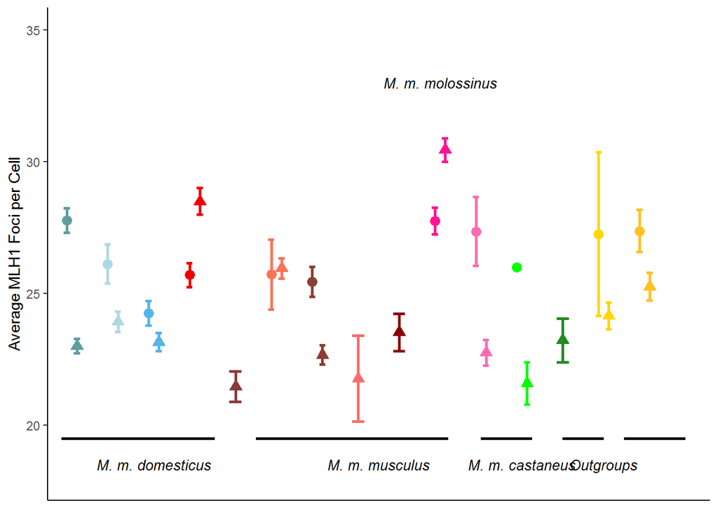

What are the steps the each chunks walk through.

#### Proportion of chrm classes

make a smaller proportion chrm block –

These results are meant to compare the proportions of bivalents with 0,1,2 or 3 chromosomes. Most of the variation in gwRR across strains in is due to more 2COs at the ‘expense’ / trade off of 1COs. (the gwRR for most mice is low/close to the minimum)

This is also another way to score heterochiasmy (that gets around the sex chrms, i think)

The data below are from hand measured cells (not from bivalent data) generate smaller data set of chrm proportions (0CO, 1CO,2CO etc) 10 cells from each musc category. **Add Molf female**

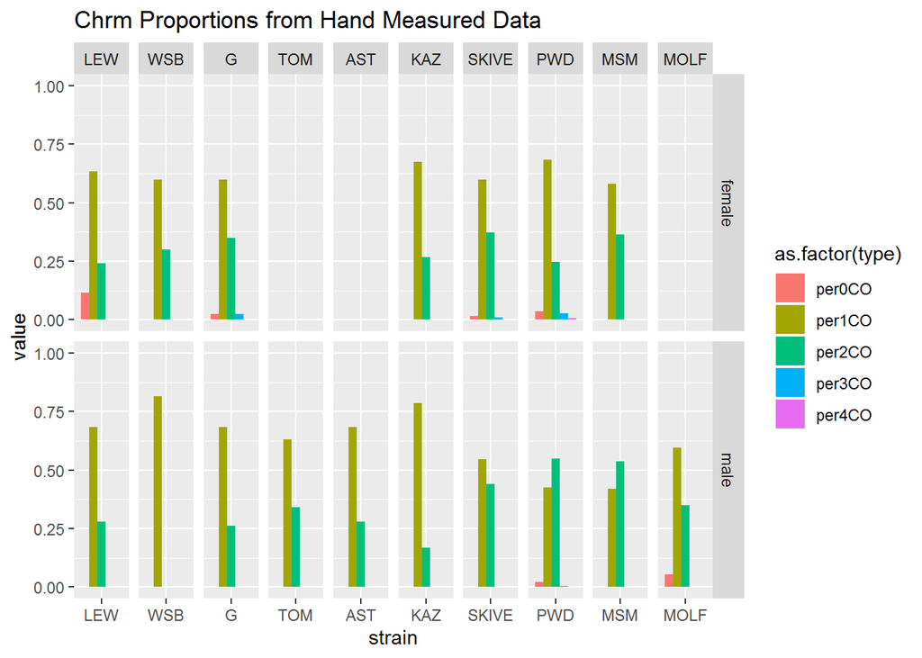

High musc males have half 1CO and 2CO bivalents. For following up on the biv stuff, find ways to compare the 1CO to 2COs in Dom and Musc. (sis-coten, length, distance from centromere).

Add p.values of tests for the how the proportions differ.

*cast female data came from another publication, add this ref (Kohler?)

The bottom lines and subspecies points don’t exactly match up.

**add in cell images like the other draft figures.**

# DMC1 Results Spermatocytes

These data are meant to test if CO precursors, double strand breaks (DSBs), are significant predictors for MLH1 count variation. Simply, do mice with more DSBs also have more COs?

ToDo: - attempt to supplement data with more KAZ DMC1 cell observations. - change all the bad variable names

The counts look close to normal.

Potentially figure 2. Using a function to display the p-vales for mean comparison

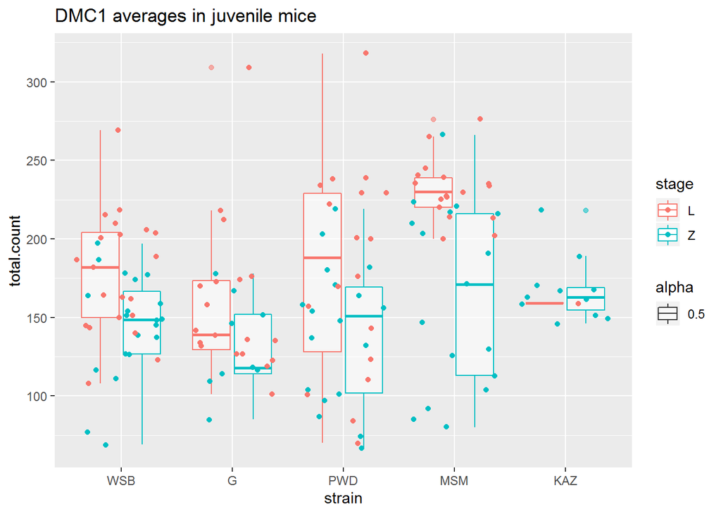

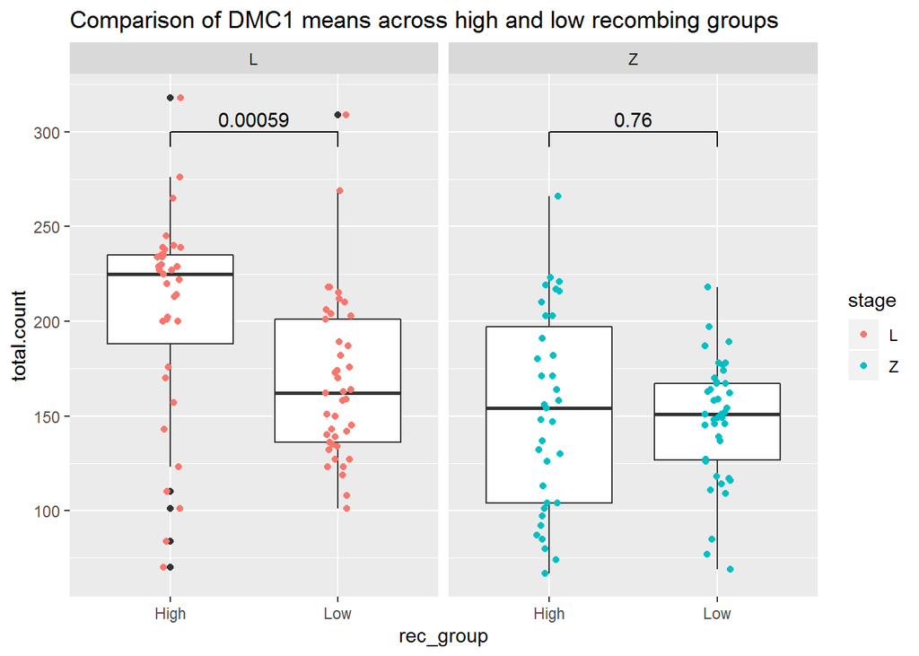

Summary:

The distributions of counts is close to normal (also the higher count is better than the MLH1 counts)

Foci of DMC1 were scored from Leptotene and Zygotene spermatocytes of juvenile mice (12-14-18 days). One mouse represents each strain. The main comparison to examine is that between the high (PWD and MSM) and low recombining (WSB, G, KAZ) strains.

ToDo think of ways to add in the compared means for the high and low groups (across cell stage) how similar are G-WSB or PWD-MSM to each other?

## DMC1 Permutations with equal sampling

> At what stage are DMC1 foci numbers most correlated with MLH1?

The correlation with MLH1 and leptotene cells is 0.8736143.

The correlation with MLH1 and zygotene cells is 0.284302.

Evidence for non-equal variance across strains for zygotene cells.

Ideas for post-hoc tests, remove strains 1 at a time and test variance. Test variance for L cells without KAz.

From ANOVA analysis strain is significant for Leptotene cells but not Zygotene cells. (but take these results with a grain of salt before assumptions are tested.)

# Rapid male specific evolution

list out the points which support rapid male specific evolution for MLH1 rates.

ToDo: chisq tests for difference in proportions, - within strain across sex, - males, across high and low groups - look at mouse level proportions

# Note on Heterochiasmy Definition

I present heterochiasmy as a comparison of oocyte to spermatocyte MLH1 counts, but the sex chromosomes/bivalents complicate this comparison. In females the XX bivalent is indistinguishable from the autosomes. To the meiotic recombination machinery, it is an autosome and has a similar REC landscape.

Whereas in spermatocytes the XY bivalent is visually distinct and any MLH1 where not included in the count). (I note if the and Y are paired, which they are at a high rate). The XY pair triggers a response to un-paired chromosomes and only has MLH1 foci within the PAR (the the tips of X and Y).

To make a more equivalent comparison I will estimate which bivalent is the XX in oocytes, and subtract that average REC from the category average of each strain.

1. Compile full-cell data from females (all 20 bivalents measured)
2. Look at the SC length -ranked data, extract the 3rd longest estimate average REC for this bivalent,
3. check how variable the REC is across the 1st,2nd,4th, and 5th are.

According to mouse genome website, the X is the 3rd largest chromosome by total amount of DNA (Mb).

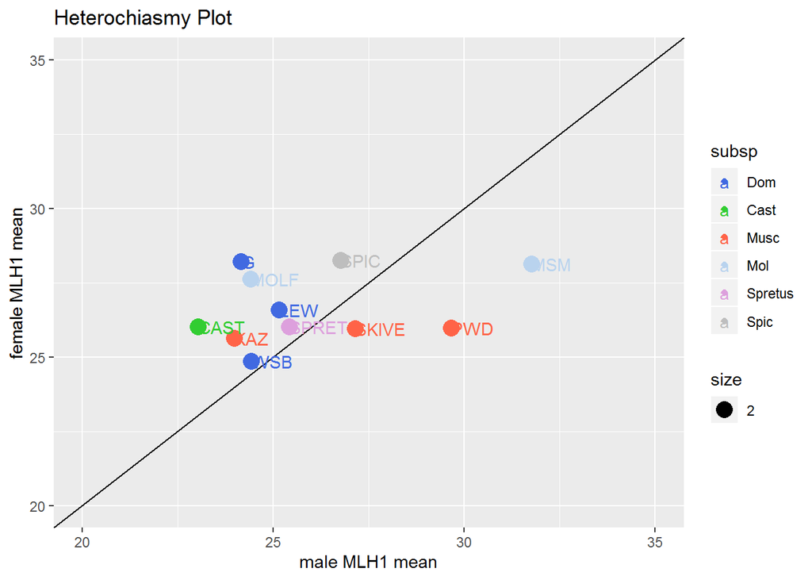

There is now MOLF, which has female biased hetC 3 of my Musc strains have male biased patter; SKIVE, PWD and MSM. 1 of the musc strains has female biased heterochiasmy, KAZ.

The mouse specific scatter plots aren’t show here because there are too bulky. These plots are in a different document.